# L’évaluation économique des biens environnementaux

Economie de l’Environnement et des Ressources Naturelles

Simon Jean

simon.jean@agroparistech.fr

AgroParisTech - CIRED - PSAE

# Introduction

## Valeur monétaire de l’environnement ?

Pourquoi chercher à donner une évaluation monétaire au vivant?

*Il ne s’agit pas de créer un marché de la biodiversité […], il s’agit de définit des valeurs de référence pour que, dans toutes les décisions publiques, soit désormais prise en compte la valeur économique de la biodiversité*

Chantal Jouanno, 2009 - Secrétaire d’état à l’écologie

*In the age of number crunchers, however, there is a danger that the more precisely expressible values will dominate the less precisely expressible values simply because their numerical chatacter makes them easier to fit into models*

Costanza and Daly, 1987, “Towards and Ecological Economics”, *Ecological Modelling*

- Il s’agit d’intégrer la protection de l’environnement et de la biodiversité dans **l’action publique**, dans l’ordre d’un calcul coûts bénéfices
  - Idée de we protect what we value
- Il s’agit aussi d’évaluer les responsabilités juridiques dans le cas des destructions environnementales

## Le préjudice écologique

- Né de la loi de 2016 pour “la reconquête de la biodiversité, de la nature et des paysages”, le préjudice écologique (Article 1246).
  - Il instaure l’obligation, pour les responsables, de réparer ce préjudice aux écosystèmes et services écosystémiques, notamment après les directives européennes de 2004 sur le sujet.
  - Il devient nécessaire de réparer l’environnement en tant que tel, pas simplement pour les préjudices indirects que l’homme perçoit.
- En 1999, le tanker *Erika* fait naufrage dans le golfe de Gascogne
  - déversant des dizaines de milliers de tonnes de fioul lourd, atteignant les côtes bretonnes.
  - Des communes se constituent alors parties civiles, pour être dédomagées du préjudice suivi, et seront finalement reconnues dans leur droit par un arrêt de la cour de cassation en 2012
  - Une amende de 200 millions d’euros de réparations à payer par … Total.
- La réparation doit être intégrale après un chiffrage des dégâts, tout en visant une restauration en nature.

## Quelles valeurs mesure-t-on?

En économie, le concept de valeur économique totale émerge des travaux de John Krutilla (1967):

- La valeur d’usage qui peut être:
  - Directe: les valeurs associées à la consommation directe de ressources issues de l’environnement (poisson, bois etc), c’est à dire aux services écosystémiques de provision ou de contributions de la nature aux populations matérielles
  - Indirecte: les valeurs associées au fonctionnement des écosystèmes, qui donnent des services écosystémiques de régulation, comme la séquestration du carbone, ou le filtrage de l’eau, ou de contributions de la nature aux populations de régulation
  - d’option: la possiblité d’utiliser dans le futur à la fois pour la préservation et l’exploitation économiques des écosystèmes jusque là préservés, ou non utilisés
- La valeur de non usage :
  - de legs : la valeur associée à la possibilité pour les générations futures de bénéficier de la nature, au travers de contributions de la nature aux populations matérielles et immatérielles
  - d’altruisme : la valeur qui correspond à la volonté de préserver l’environnement au sein d’une même génération
  - d’existence : la valeur correspondant à la protection de l’environnement pour un motif intrinsèque, délié des considérations anthropocentriques

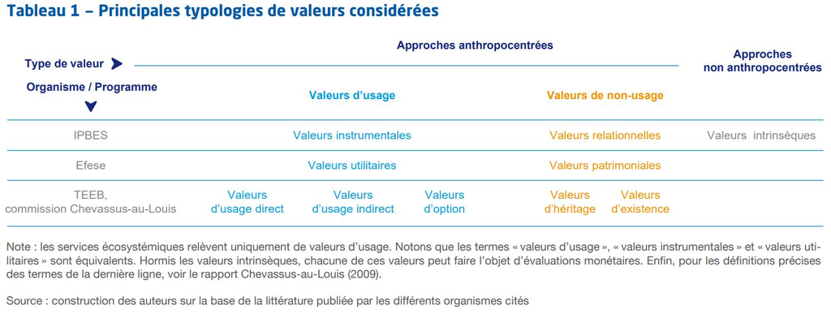

## Quelles valeurs aujourd’hui?

- [Costanza et al, 1997 dans Nature](https://www.nature.com/articles/387253a0), chiffrent le capital naturel et la valeur des services écosystémiques à plus de 30 trillions de dollars, plus large que le PIB mondial aujourd’hui
- Plus récemment, le programme Efese lancé en 2012 a tenté d’évaluer une partie des services écosystémiques en France, aboutissant à une mesure de 50 milliards par an, soit 1.8% du PIB de 2023
- Le Joint Reseach Committee de l’Union Européenne, en évaluant 8 services écosystémiques, aboutit à un chiffre plus modeste, autour de 18 milliards d’euros, soit 0.6% du PIB
  - Tout deux évaluent la pollinisation, les usages récréatigs, la séquestration du carbone etc, à différentes échelles spatiales

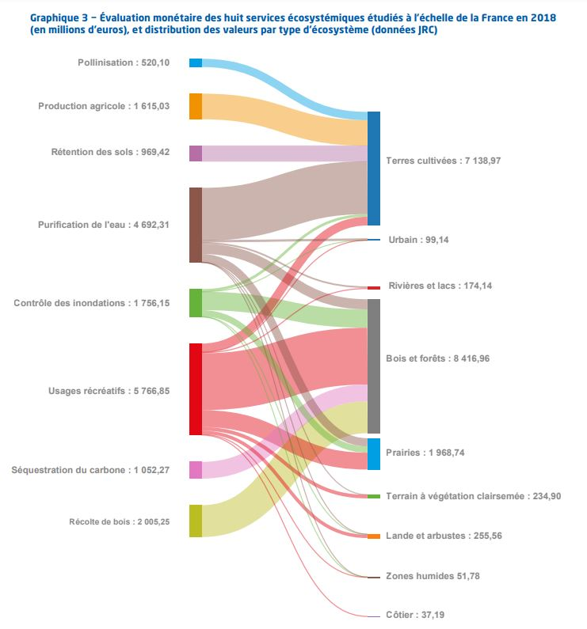

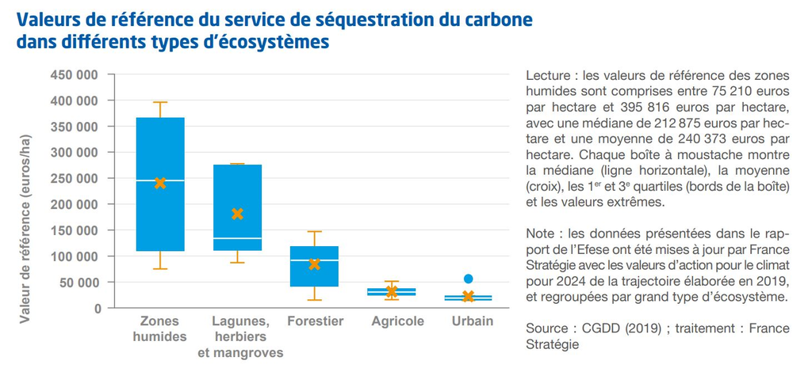

## Comment arrive-t-on à ces mesures?

Mesurer une valeur économique nécessite de :

1. Identifier clairement les éléments affectés, par une politique publique, un accident, bref, identifier une chaîne causale
2. Mesurer la relation bio-physique entre un processus environnemental et les dommages causés aux éléments identifiés
3. Estimer les changements qu’opèrent les éléments affectés, pour absorber les conséquences des processus environnementaux
4. Placer une valeur monétaire sur les conséquences inabsorbées

## Toutes les mesures de valeurs se valent-elles?

- Les valeurs les plus simples à mesurer sont celles d’usage direct
  - On a des prix de marché que l’on peut utiliser, qui font se rencontrer les préférences et la technologie : c’est le gold standard de l’évaluatio
  - Ou encore des coûts de remplacement, plus ou moins explicites, bien qu’ils n’aient pas la partie “adaptation” dans les cas purement techniques
- Les valeurs d’usage indirectes n’ont bien souvent pas de prix de marché :
  - Le prix d’un écosystème, par ses fonctions diverses (de production, de régulation, culturelles) est difficile à déterminer
  - Mais certaines propriétés d’usages concomittants peuvent nous aider à les mesurer : des coûts d’évitement, des variations communes de prix, ou encore des proxies qui nous disent les choix
- Les valeurs de non usage sont les plus difficiles à mesurer :
  - Quelle serait la valeur d’héritage, ou d’altruisme?
  - Comment faire pour qu’elles aient une “épaisseur”, une réalité, quand elles ne donneront pas lieu à des échanges économiques?

## Panorama des méthodes

1. Les méthodes par préférences (ou comportements) révélées: sont basées sur les comportements des gens, sur les transactions véritablement réalisées, c’est le gold standard
   - Principalement utilisées pour les valeurs d’usage
2. Les méthodes par préférences (ou comportements) déclarées: sont basées sur des comportements déclarés, où l’on pas réellement pu observer les comportements des gens
   - Principalement utilisées pour les valeurs de non usage
3. La méthode des transferts de bénéfices : face à la difficulté de réaliser de nouvelles études, on utilise parfois les résultats d’études existantes dans un contexte différent pour connaître localement les valeurs
4. Des méthodes composites :
   - Utilisant des modélisations intégrées des dommages bio-physiques avec des modèles de choix,
   - Des méthodes identifiant précisément les éléments affectés, les mécanismes biophysiques et leurs conséquences, et les changements opérés, en restant sur des métriques non-monétaires, notamment via de l’inférence causle

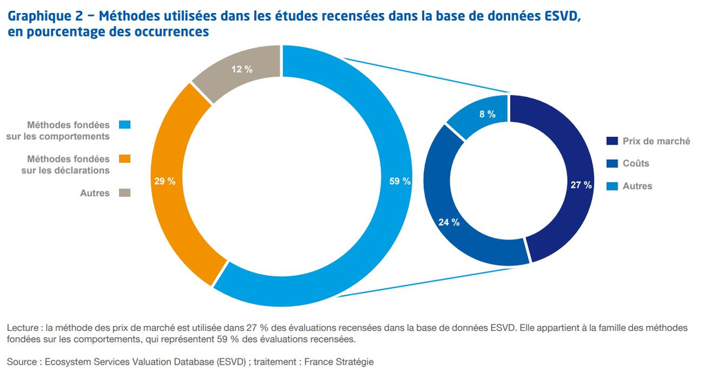

# Les méthodes par préférences révélées

## Bénéfices, consentement à payer et dommages

- Pour avoir la valeur des biens, on voudrait avoir la mesure du surplus associé à un bien.
- Ceci dit, il n’y a pas de marché pour l’environnement dans la majeure partie des cas
  - On ne peut pas directement utiliser les prix et les quantités échangées
- On va se focaliser sur la demande plutôt que sur l’offre dans la plupart des cas
  - On veut comprendre la valeur que placent les consommateurs sur les biens environnementaux
  - On verra comment prendre en compte les côtés liés à l’offre, pour avoir une disposition marginale à payer nette
- Exemple : on veut mesurer les bénéfices totaux de la réduction de la pollution, c’est à dire la réduction des dommages totaux liés à la pollution
- Pour faire cela, on veut mesurer l’intégralité des bénéfices marginaux liés à la réduction de la pollution
  - Le bénéfice marginal est l’opposé du dommage marginal d’une tonne de pollution
  - La disposition marginale à payer est le bénéfice marginal lié à la réduction d’une tonne de pollution

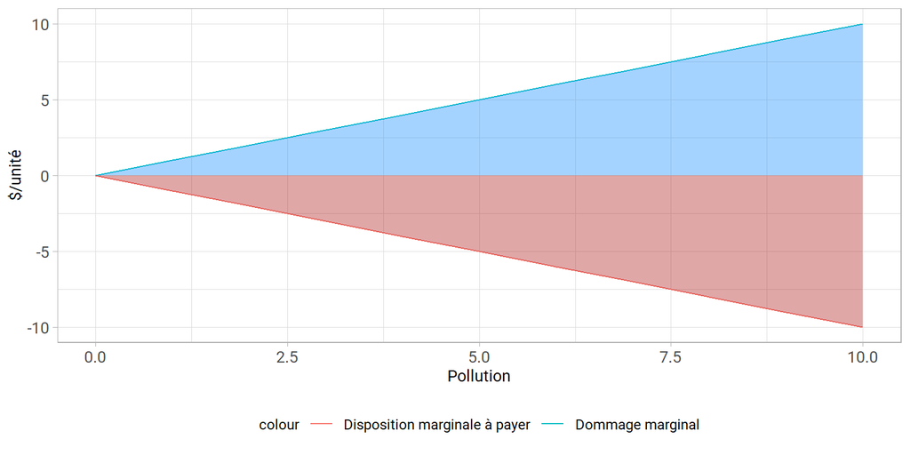

## Mesurer des dispositions marginales à payer par des approches révélées

- L’idée de fond est de reconstruire cette courbe de disposition marginale à payer en utilisant des biens connexes
- Rappel de micro :
  - Les agents maximisent leur utilité $U(\mathbf{x})$ où $\mathbf{x}\in \mathbb{R}^N$ est un panier de biens, sous contrainte de revenu
  - On en déduit des fonctions de demande $\mathbf{x}^*(\mathbf{p}, R)$ où $\mathbf{p}\in \mathbb{R}^N$ est le vecteur des prix
  - Supposons que l’on a $x$ un bien de consommation et $q$ un bien environnemental
  - Dans le cas des biens environnementaux, on n’aura pas de prix!
- On pourra observer ceci dit une relation $x(p_x, q)$ c’est à dire une quantité de bien de consommation consommée en fonction de son prix et de la qualité environnementale, que l’on nomme demande restreinte
  - On pourrait ensuite mesurer la variation de la disposition à payer rapportée
  - A la variation d’une quantité de bien environnemetal
    $$\Delta DAP / \Delta q = f(p_x, q) = DMAP$$

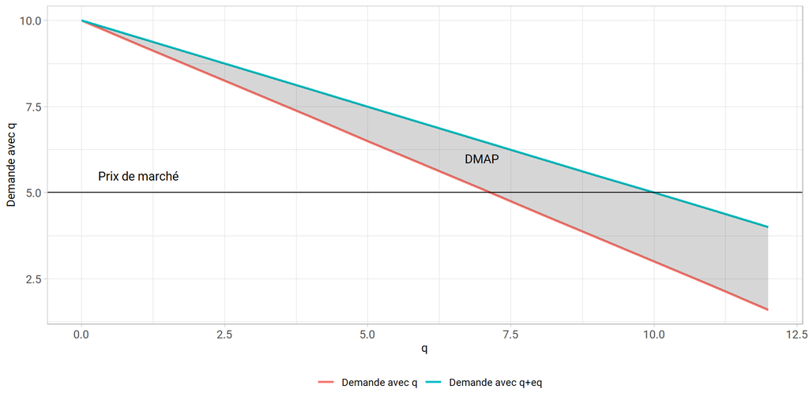

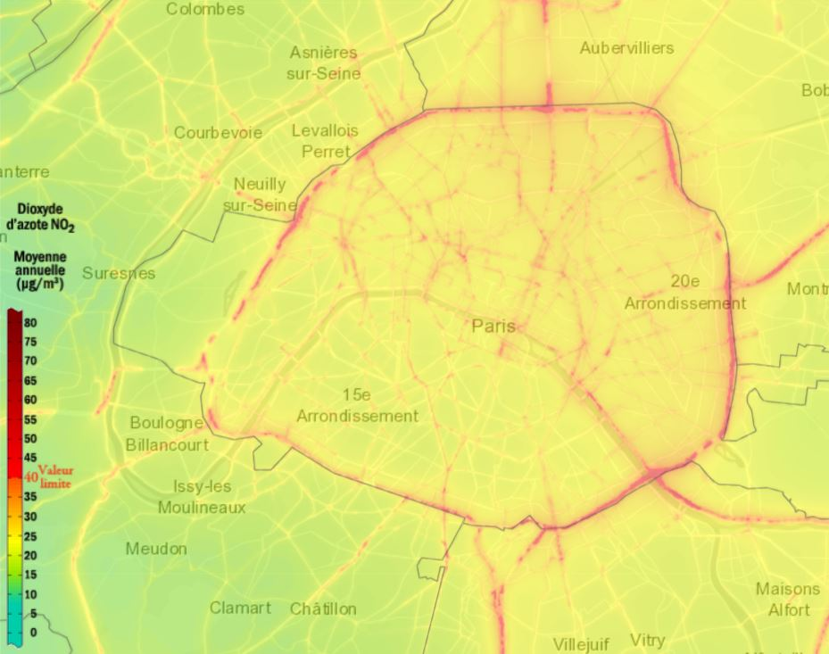

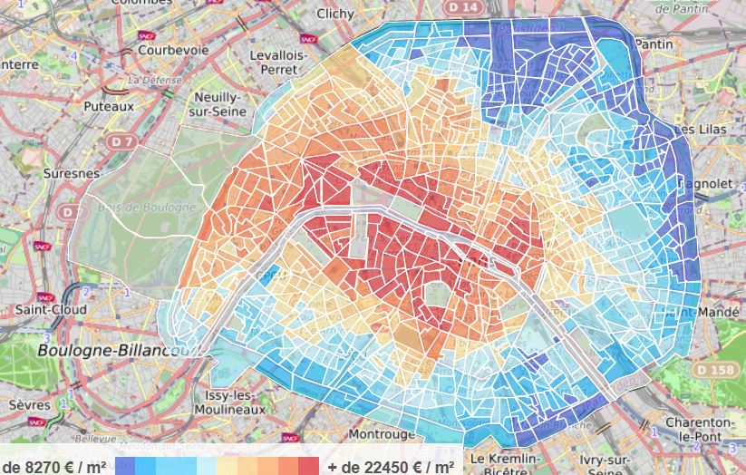

## Différentes approches pour différents types de biens

Les biens peuvent être soit :

- Des substituts
  - Lorsque le prix de l’un augmente, la consommation de l’autre augmente
  - Symmétriquement, on peut augmenter sa consommation si l’autre est réduite
  - On utilisera les méthodes par approche de coût de remplacement ou d’évitement
  - Où les dépenses en bien privé augmentent à mesure que la qualité environnementale décroît (corrélation inverse)
- Des compléments :
  - Lorsque le prix de l’un augmente, la consommation de l’autre baisse
  - Symmétriquement, on consomme autant de l’un que de l’autre
  - On utilisera les méthodes par coûts de transport
  - Où les dépenses en bien privé correspondent au niveau de qualité environnementale (corrélation positive)
- Appréciés en tant que paquets, en tant qu’attributs d’un bien plus grand:
  - Cela n’a pas de lien avec la substituabilite ou la complémentarité
  - Mais certains biens sont faits de beaucoup de caractéristiques (voitures, maisons etc) : l’évolution d’une des caractéristiques peut entraîner des changements de valeur d’un bien marchand
  - On utilisera les méthodes d’évaluation hédoniques

## Forces et faiblesses des méthodes par préférences révélées

L’idée est simple : mesurer à partir d’éléments économiques reliés de façon proche, pour lesquels on a un marché

- Basé sur de vrais comportements économiques
  - Donnant des données proches du monde économique
  - Evitant les biais d’enquêtes
- Des études relativement rentables (i.e pas chères)
  - Usage de données déja collectées
  - Pas de coûts d’enquête
- Ne capturent que les valeurs d’usage
  - Au mieux partielle : tous les services écosystémiques n’ont pas de contrepartie clairement identifiable
  - Ne permet pas de voir les autres valeurs, notamment de non usage
- Se basent sur des conditions parfois restrictives
  - Notamment sur l’état des marchés connectés (compétition imparfaites)
  - ou l’absence de comportement stratégiques
- Extrapolent des évaluations marginales du consentement à payer
  - La DMATP n’est peut être pas linéaire
  - L’extrapolation au vu de grands changements environnementaux n’est peut être pas valide

## Coûts évités

## Méthode des coûts de transport

## Méthode hédonique

# Les préférences déclarées

## Revealed preferences

Attention, les coûts d’ingénierie et de remplacement ne prennent pas bien en compte la partie numéro 3, c’est à dire la possible nouvelle adaptation.